# LEMO: hoe moet je een feedback rapport interpreteren?

Een experiment met scrollytelling

Je vulde eerder de LEMO-vragenlijst in en kreeg een feedback rapport. Maar hoe moet je dat rapport nu interpreteren? In deze “scrollytelling” leggen we je uit hoe je dat doet.

# Waarvoor staat LEMO?

LEMO is een samentrekking van de woorden

**Leerstrategieën**

Leerstrategieën zijn manieren waarop je de leerstof aanpakt. Een schema maken bij een hoofdstuk is een voorbeeld van een leerstrategie.

en

**Motivatie**

Motivatie beschrijft de redenen waarom je studeert en hoe je je daarbij voelt. Studeren omdat je later een bepaalde job wil uitoefenen is een voorbeeld van motivatie.

De LEMO-vragenlijst peilt dus naar **hoe** je studeert (jouw leerstrategieën) en **waarom** je studeert (jouw motivatie).

# Wat meet LEMO precies?

De LEMO-vragenlijst brengt **vier** componenten van je leerproces in kaart.

Twee componenten hebben te maken met leren

en

Twee componenten hebben te maken met motivatie

We bekijken elk aspect in detail.

## Verwerkingsstrategieën

**Verwerkingsstrategieën** beschrijven wat je doet om de leerstof te verwerken. Dat gaat van dingen van buiten leren tot verbanden leggen, voorbeelden zoeken of kritische vragen stellen.

- *Relateren en structureren* of de mate waarin je de leerstof onderling verbindt en ordent.
- *Kritisch verwerken* of de mate waarin je de leerstof in vraag stelt.
- *Concretiseren* of de mate waarin je de leerstof toepast en linkt met je eigen leefwereld.
- *Samen leren* of de mate waarin je graag met andere studenten samenwerkt en de mate waarin je hen om feedback vraagt.
- *Memoriseren* of de mate waarin je de leerstof van buiten leert.
- *Analyseren* of de mate waarin je de leerstof op een systematische manier aanpakt.

## Sturingstrategieën

**Sturingsstrategieën** beschrijven hoe je je leerproces organiseert. Dat gaat van plannen van je leerproces tot het opvolgen van je vooruitgang en het bijsturen wanneer dat nodig blijkt.

In Lemo bevragen we drie sturingsstrategieën:

- *Zelfsturing* of de mate waarin je de organisatie van jouw leerproces zelf in handen pakt.
- *Planning en tijdsbeheer* of de mate waarin je jouw leerproces op voorhand plant, deze planning opvolgt en bewust kijkt hoe je met jouw tijd omgaat.
- *Stuurloos leergedrag* of de mate waarin moeilijkheden ervaar om je leerproces te organiseren.

## Motivatie

**Motivatie** beschrijft waarom je studeert. Dat gaat van interesse in de leerstof over het willen uitvoeren van een specifieke job tot het willen voldoen aan de verwachtingen van anderen (je ouders bij voorbeeld).

In Lemo bevragen we drie motivationele drijfveren:

- *Willen studeren* of de mate waarin je er zelf voor kiest om te studeren. Deze keuze kan voortkomen uit interesse in de leerstof of omdat je begrijpt dat je studie noodzakelijk is voor een job die je later wil uitvoeren .
- *Moeten studeren* of de mate waarin je je gedwongen voelt om te studeren. Deze druk kan van buitenaf komen. Je ouders en leerkrachten hebben bepaalde verwachtingen waaraan je wil voldoen. Je kan jezelf die druk ook opleggen omdat je het bij voorbeeld minstens even goed wil doen dan je broer.
- *Demotivatie* of de mate waarin je het moeilijk vindt om je te motiveren voor je studie. Misschien was de opleiding niet wat je ervan verwachtte, vind je de opleiding te moeilijk of te makkelijk of voel je je niet helemaal thuis.

## Bekwaamheidsgevoel

**Bekwaamheidsgevoel** beschrijft hoe je jezelf inschat in je studie. Dat gaat van het vertrouwen in je eigen manier van studeren tot het gevoel dat je niet goed genoeg bent.

# Hoe moet je scores in jouw feedbackrapport interpreteren?

Hiernaast zie je een figuur uit het LEMO-rapport. Deze figuur geeft de leersterkten van een student weer. Ze geeft je een overzicht van de 3 vaardigheden waarop je de hoogste score haalt. Die score ligt tussen 0 en 4.

Het middelpunt van de schaal ligt bijgevolg op 2

Op basis onderzoek verdeelden we de schaal op in vijf stukken. De kleur van de balk toont je in welk stuk jouw score valt en hoe je die score moet interpreteren.

Een rode achtergrondkleur betekent dat deze vaardigheid nog echt een werkpunt voor je is.

Een groene achtergrondkleur betekent dat je hier al heel sterk in bent.

De okergele kleur toont je dat je hierin al enige vaardigheid bezit, maar dat er nog ruimte is om te groeien

Terug naar onze figuur. Hoe moeten we dan onze scores interpreteren?

[figure not shown]

LE  
MO

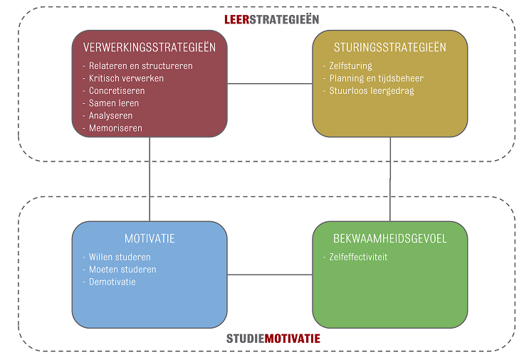

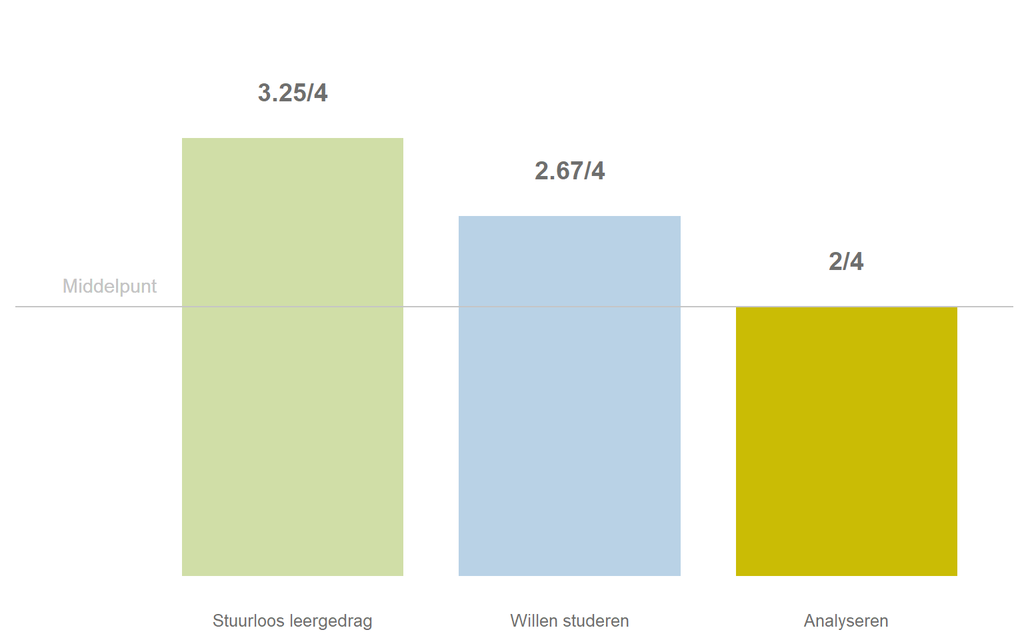

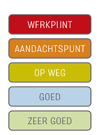

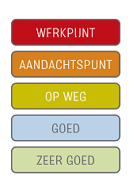

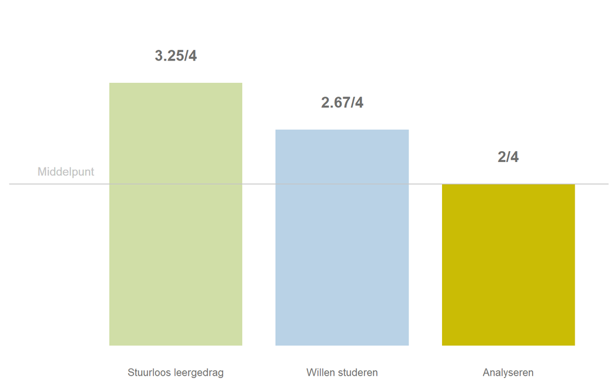